# Implementation of LASSO-Logistic regression.

4/1/2020

## Synopsis

This project showcases the manual implementation of the LASSO algorithm with logistic regression in R. We compare our implementation to the gold-standard implementation in the R package `{glmnet}` by Jerome Friedman et. al. in classifying malignant (M) and benign (B) tumors from images of breast cancer tumors recorded in the `breast-cancer.csv` data of from the UCI machine learning repository.

We show our manual implementations in R of the following algorithms:  
- Newton-Raphson optimizer with step-halving and re-direction steps  
- Logistic regression algorithm, using Newton-Raphson optimizer  
- LASSO regression extension to logistic regression, using a coordinate descent optimizer

Our implementation are shown to be comparable to gold-standard implementations in R. The source code can be found in the source_code folder.

## Data description

The data `breast-cancer.csv` have 569 row and 33 columns. From the UCI repository:

> Features are computed from a digitized image of a fine needle aspirate (FNA) of a breast mass. They describe characteristics of the cell nuclei present in the image

There are 357 benign and 212 malignant cases in the `diagnosis` column which will be our outcome variable for logistic regression. There are 30 columns corresponding to the mean, standard deviation, and largest values (points on the tails) of the following 10 features computed for each cell nucleus.

- radius (mean of distances from center to points on the perimeter)
- texture (standard deviation of gray-scale values)
- perimeter
- area
- smoothness (local variation in radius lengths)
- compactness (perimeter^ 2 / area - 1.0)
- concavity (severity of concave portions of the contour)
- concave points (number of concave portions of the contour)
- symmetry
- fractal dimension (“coastline approximation” - 1)

**Our goal is to use LASSO-logistic regression to build a predictive model using the 30 feature columns to predict if a case is either malignant or benign.**

### Data import and clean-up

We import the data and study the correlation structure.

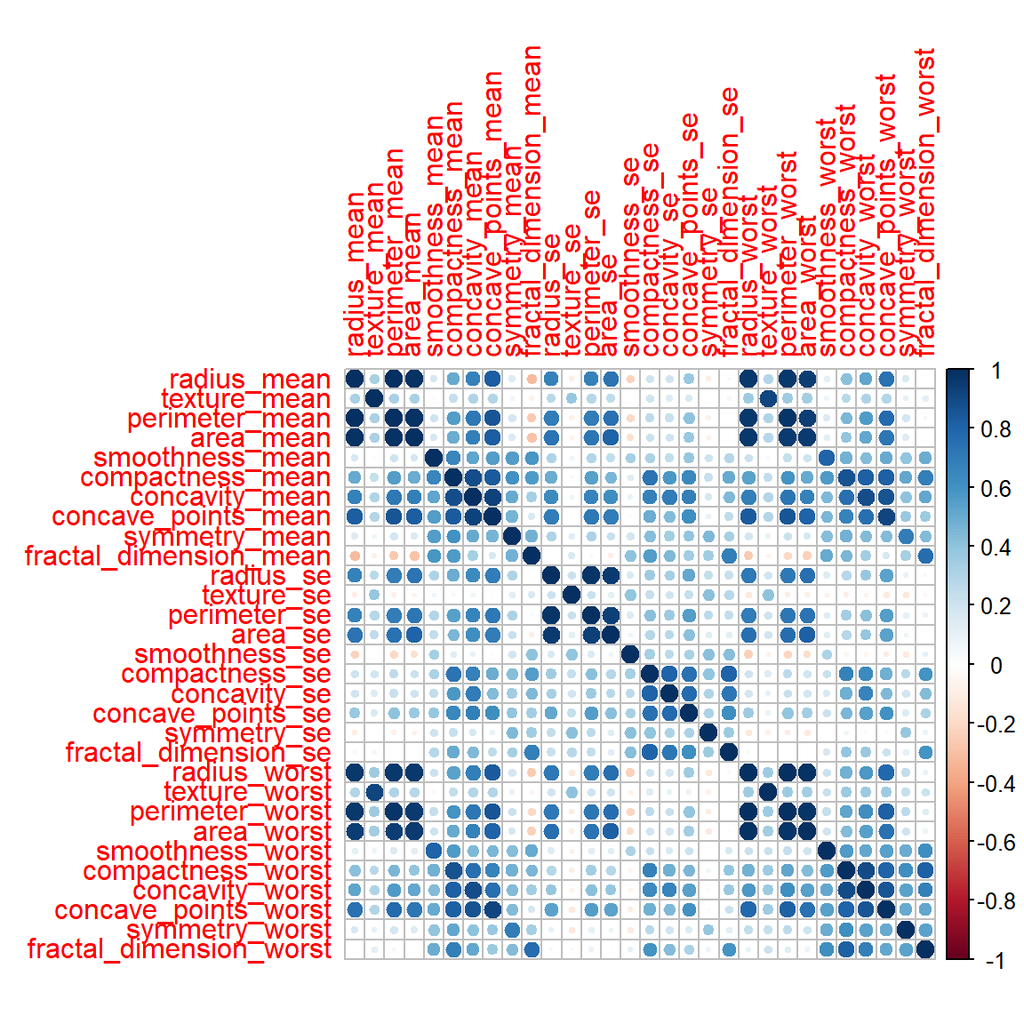

```r
breast_raw<- read.csv(paste0(
        here::here(),"/data/breast-cancer.csv"),
                  row.names = NULL) %>% janitor::clean_names() %>%
        select(-id,-x)

corr_matrix <- cor(breast_raw %>% select(-diagnosis,))
corrplot(corr_matrix)
```

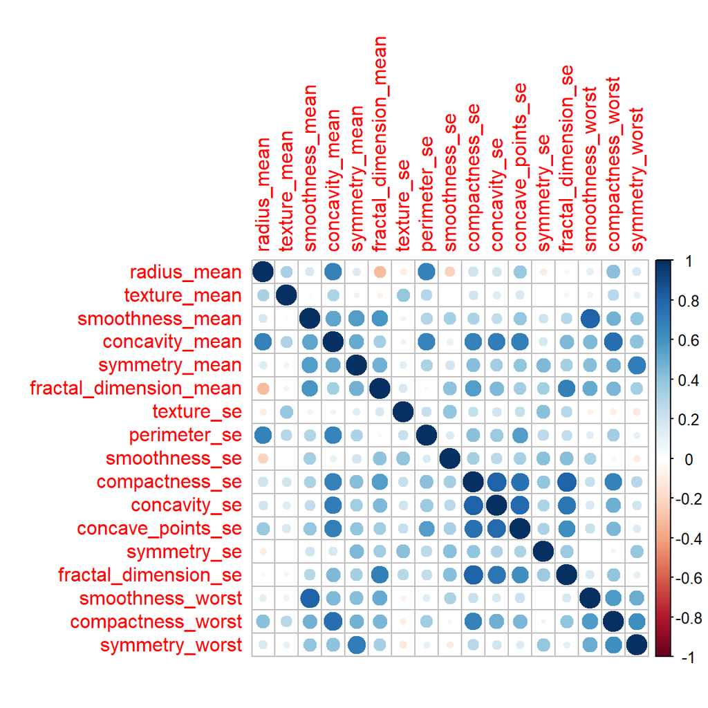

```r
breast<-breast_raw %>% select(-perimeter_mean,-area_mean,-radius_worst,
                              -radius_se,-perimeter_worst,-area_worst,
                              -texture_worst,-concave_points_worst,
                              -area_se,-concave_points_mean,
                              -compactness_mean,-concavity_worst,
                              -fractal_dimension_worst
                              ) %>%
        mutate(across(.cols = -diagnosis,
                      .fns = function(x){return((x-mean(x))/sd(x))}))

breast_no_int<-breast %>% mutate(diagnosis = ifelse(diagnosis == "M",1,0))
breast_int<- cbind(intercept = 1,breast_no_int)

corr_matrix_1 <- cor(breast_no_int %>% select(-diagnosis,))
corrplot(corr_matrix_1)
```

This correlogram correspond to the cleaned version of the data we are using to fit our results.

## Implementations

### Logistic regression

A logistic regression algorithm is used to regress a linear combination of features to a continuous outcome (probability from 0 to 1) using the logit link function. To accomplish this, we need two parts: 1) a function that calculate the likelihood, gradient, and hessian of our model, and 2) an optimizer that finds the maximum likelihood using the gradient and hessian as the input. The following is the former part. The likelihood is calculated as:
$$\sum \textbf{Y} \cdot (\textbf{X}\beta-log(1+exp(\textbf{X}\beta))+(1-\textbf{Y}) \cdot (-log(1+ exp(\textbf{X}\beta)))$$
The gradient is calculated as:
$$\textbf{X}(\textbf{Y}-\frac{exp(\textbf{X}\beta)}{1+exp(\textbf{X}\beta)})$$
The Hessian is calculated as:
$$\textbf{-X}^Tdiag(\frac{exp(\textbf{X}\beta)}{1+exp(\textbf{X}\beta)})\textbf{X}$$

```r
logistic_mle <- function(dat, beta_vec, response = "diagnosis", refit = T) {
        # y_mat is the outcome column
        y_mat <- matrix(as.vector(dat[[response]]), ncol = 1)

        # x_mat is the feature dataset, with an extra column of 1 for intercept
        x_mat <- cbind(1,as.matrix(dat[, which(names(dat) != response)]))

        mu <- x_mat %*% beta_vec
        pi <- exp(x_mat %*% beta_vec)

        likelihood <- sum(y_mat * (mu - log(1 + pi))
                          + (1 - y_mat) * (-log(1 + pi)))

        grad <- t(x_mat) %*% (y_mat - pi / (1 + pi))

        hess <- -t(x_mat) %*% diag(as.vector(pi / (1 + pi) ^ 2)) %*% x_mat

        return(list(loglik = likelihood, grad = as.vector(grad), Hess = hess))
}
```

### Newton-Raphson optimizer

The Newton-Raphson optimizer, with step-halving and re-direction steps, is used to find the direction of the steepest descent to a local minima (or equivalently ascent to a local maxima with the opposite sign) by solving for the system of equations of gradient = 0. More details can be found in this [wikipedia page](https://en.wikipedia.org/wiki/Newton%27s_method_in_optimization). We use this to find the MLE of our logistic regression algorithm.

```r
newton_raphson <- function(dat, fun, start, tol=1e-10,
                          maxiter = 200, n_halves = 10,
                          original_lambda = 1, beta_name = NULL) {
        i <- 0
        current <- start
        fit <- fun(dat, current)

        lambda <- original_lambda # To allow for halves stepping
        times_halved <- 0

        res <- c(0, fit$loglik, current, lambda, times_halved)

        prevloglik <- -Inf # To make sure it iterates

        while (i < maxiter && abs(fit$loglik - prevloglik) > tol)
        {
                i <- i + 1
                prevloglik <- fit$loglik
                prev <- current
                current <- prev - lambda * solve(fit$Hess) %*% fit$grad
                while (((fun(dat, current)$loglik < fun(dat, prev)$loglik) &&
                        times_halved < n_halves) |
                       is.infinite(fun(dat, current)$loglik)) {
                        times_halved <- times_halved + 1
                        lambda_1 <- lambda * (1 / 2) ^ (times_halved)
                        current <-
                                prev - lambda_1 * solve(fit$Hess) %*% fit$grad
                }

                fit <- fun(dat, current)
                res <- rbind(res, c(i, fit$loglik, current, lambda, times_halved))
                lambda <- original_lambda
                times_halved <- 0
        }
        colnames(res) <- c("iter","llik",
                           "intercept",beta_name,
                           "lambda", "times_halved")
        rownames(res) <- NULL
        res<-data.frame(round(res, 4))
        res$real_lambda = res$lambda * 0.5^(res$times_halved)
        estimates = tibble(term = c("intercept",beta_name),
                           coefficient = as.vector(current))

        return(list(iter = res,
                    estimates = estimates))
}
```

### LASSO-Logistic Regression

The lasso logistic regression algorithm can use soft-thresholding and coordinate descent to find the solutions of the $\beta$ estimates. With the implemented “warm start”, our algorithm have a comparable rate of convergence to the Newton-Raphson algorithm. Details can be found in Hastie et. al. 2015.

```r
soft_threshold = function(beta, lambda) {
        ifelse(abs(beta)>lambda && beta > 0,
               beta-lambda,
               ifelse(abs(beta) > lambda && beta < 0,
                      beta + lambda,0))
        }

logistic_lasso <- function(data, y, lambda, beta_vec, tol = 1e-10,
                           maxiter = 200, beta_name = NULL){
        i <- 0
        x_mat <- as.matrix(data)
        x_center<-attributes(x_mat)$`scaled:center`
        x_scale<-attributes(x_mat)$`scaled:scale`

        loglik <- 0
        res <- c(0, loglik, beta_vec)
        prevloglik <- Inf
        while (i < maxiter && abs(loglik - prevloglik) > tol && loglik < Inf){
                i <- i + 1
                prevloglik <- loglik
                for (k in 1:length(beta_vec)){
                        u <- x_mat %*% beta_vec
                        expu <- exp(u)
                        p <- expu/(1 + expu)
                        weight <- p*(1-p)

                        #Make sure weight doesn't overflow
                        weight <- ifelse(abs(0-weight) < 1e-7, 1e-7, weight)

                        #calculate working responses
                        zi <- u + (y-p)/weight

                        #calculate the residual
                        residual <- x_mat[,-k] %*% beta_vec[-k]

                        #calculate beta soft-threshold
                        beta_vec[k] <- soft_threshold(mean(weight*x_mat[,k]*
                         (zi-residual)),lambda)/(mean(weight*(x_mat[,k]^2)))}

                #Current Likelihood
                loglik <- 1/(2*nrow(x_mat))*sum(weight*(zi-x_mat%*%beta_vec)^2)
                + lambda*sum(abs(beta_vec))
                res <- rbind(res, c(i, loglik, beta_vec))
        }
        colnames(res)<-c("iter","llike",beta_name)
        estimates = tibble(term = beta_name,
                           coefficient = (as.vector(beta_vec)))

        return(list(iter = res,
                    estimates = estimates))
}
```

## Results

### Logistic Regression

We fit our logistic implementation to classify image “M” as 1 and “B” as 0. We use our Newton-Raphson function for optimization. We also compare our function estimate to `{glmnet}` estimates.

```r
ans <- newton_raphson(breast_no_int,
                     logistic_mle,
                     rep(0,ncol(breast_no_int)),
                     maxiter = 200, n_halves = 20, original_lambda = 1,
                     beta_name = names(breast_no_int)
                     [which(names(breast_no_int) != "diagnosis")])

############################# FIT WITH GLMNET FOR COMPARISION ##################
test_dat <- breast_no_int %>%
        mutate(diagnosis  = factor(diagnosis , levels = c(0,1)))

my_rec<-recipe(diagnosis  ~., data = test_dat)

# With penalty term = 0, this is equivalent to a logistic regression model
my_model <- logistic_reg(penalty = 0, mixture = 1) %>%
        set_engine("glmnet") %>%
        set_mode("classification")

wf <- workflow() %>%
        add_recipe(my_rec) %>% # Workflow
        add_model(my_model)

# Compare the betas of the model with the true beta
fit_data <- wf %>%
        fit(test_dat) %>%
        pull_workflow_fit() %>% tidy()

################################################################################
logistic<-tibble(ans$estimates,
              glmnet_estimates = fit_data$estimate)%>%
        mutate(across(.cols = where(is.numeric),.fns = function(x)round(x,4))) %>%
        rename(newton_logistic = coefficient)
```

The following table shows the beta estimates of our logistic implementation and `{glmnet}`. Our function performs comparably to `{glmnet}`.

```r
logistic %>% knitr::kable()
```

| term | newton_logistic | glmnet_estimates |
| --- | --- | --- |
| intercept | -0.6229 | -0.6217 |
| radius_mean | 3.7531 | 3.7014 |
| texture_mean | 1.7115 | 1.6854 |
| smoothness_mean | -0.0290 | 0.0000 |
| concavity_mean | 3.9638 | 3.8181 |
| symmetry_mean | -0.7934 | -0.7028 |
| fractal_dimension_mean | -0.9443 | -0.8993 |
| texture_se | 0.3177 | 0.2808 |
| perimeter_se | 3.4739 | 3.3334 |
| smoothness_se | -0.1801 | -0.1550 |
| compactness_se | -1.1806 | -1.1236 |
| concavity_se | -0.2796 | -0.2342 |
| concave_points_se | 0.8336 | 0.7343 |
| symmetry_se | -1.4438 | -1.4010 |
| fractal_dimension_se | -0.7971 | -0.7674 |
| smoothness_worst | 1.7811 | 1.7219 |
| compactness_worst | 0.3102 | 0.2661 |
| symmetry_worst | 2.6700 | 2.5554 |

### LASSO-logistic regression

#### Lambda = 0

We compare the results of our `logistic_lasso` function at $\lambda = 0$ to our Newton-Raphson logistic function and `{glmnet}` to make sure that soft-thresholding with $\lambda = 0$ yields the same results.

```r
# separate x and y to calculate lambda max
breast_int_x<-breast_int[,which(names(breast_int) != "diagnosis")]
breast_int_y<-breast_int[,"diagnosis"]
# calculate lambda max

log_lasso<-logistic_lasso(data=breast_int_x,
                      y = breast_int_y,
                      lambda = 0,
                      beta_vec = as.matrix(rep(0,ncol(breast_int_x)),ncol = 1),
                      beta_name = c(names(breast_int_x)
                                    [which(names(breast_int_x) != "diagnosis")]))
log_lasso_res<-tibble(logistic,
                our_logistic_lasso = log_lasso$estimates$coefficient) %>%
        mutate(across(.cols = where(is.numeric),.fns = function(x)round(x,4)))
log_lasso_res %>% knitr::kable()
```

| term | newton_logistic | glmnet_estimates | our_logistic_lasso |
| --- | --- | --- | --- |
| intercept | -0.6229 | -0.6217 | -0.6227 |
| radius_mean | 3.7531 | 3.7014 | 3.7530 |
| texture_mean | 1.7115 | 1.6854 | 1.7114 |
| smoothness_mean | -0.0290 | 0.0000 | -0.0282 |
| concavity_mean | 3.9638 | 3.8181 | 3.9638 |
| symmetry_mean | -0.7934 | -0.7028 | -0.7932 |
| fractal_dimension_mean | -0.9443 | -0.8993 | -0.9448 |
| texture_se | 0.3177 | 0.2808 | 0.3178 |
| perimeter_se | 3.4739 | 3.3334 | 3.4743 |
| smoothness_se | -0.1801 | -0.1550 | -0.1792 |
| compactness_se | -1.1806 | -1.1236 | -1.1824 |
| concavity_se | -0.2796 | -0.2342 | -0.2788 |
| concave_points_se | 0.8336 | 0.7343 | 0.8328 |
| symmetry_se | -1.4438 | -1.4010 | -1.4438 |
| fractal_dimension_se | -0.7971 | -0.7674 | -0.7970 |
| smoothness_worst | 1.7811 | 1.7219 | 1.7798 |
| compactness_worst | 0.3102 | 0.2661 | 0.3123 |
| symmetry_worst | 2.6700 | 2.5554 | 2.6699 |

Our estimates are very similar, indicating that our implementations works well.

#### Lambda > 0

We find the maximum $\lambda$ that will shrink all our beta estimates to 0.

```r
lambda_max<-max((t(as.matrix(breast_int_x)) %*% breast_int_y)/nrow(breast_int_x))
lambda_max
```

```
## [1] 0.3725835
```

With $\lambda_{max} = max_l\frac{<X_lY>}{N}=0.3725835$, we make a sequence from 0 to 0.4, by 0.02 per step and make path plots.

```r
lambda_seq<-seq(from = 0, to = 0.4, by = 0.02)

path_lasso_custom<-function(my_seq){
        for_map<-function(x){
                res_1<-logistic_lasso(data=breast_int_x,
                      y = breast_int_y,
                      lambda = x,
                      beta_vec = as.matrix(rep(0,ncol(breast_int_x)),ncol = 1),
                      beta_name = c(names(breast_int_x)
                                    [which(names(breast_int_x) != "diagnosis")]))
                res_2<- res_1$estimates %>% mutate(penalty = x,
                                                   func = "logistic_lasso")
        }
        res<-map(my_seq,for_map) %>% reduce(rbind) %>%
                mutate(term = ifelse(term == "intercept", "(Intercept)",term))
        res
}

path_lasso_glmnet<-function(my_seq){
        test_dat <- breast_no_int %>%
                        mutate(diagnosis  = factor(diagnosis , levels = c(0, 1)))

                my_rec <- recipe(diagnosis  ~ ., data = test_dat)

        for_map<-function(x){

                my_model <- logistic_reg(penalty = x, mixture = 1) %>%
                        set_engine("glmnet") %>%
                        set_mode("classification")

                wf <- workflow() %>%
                        add_recipe(my_rec) %>% # Workflow
                        add_model(my_model)

                # Compare the betas of the model with the true beta
                fit_data <- wf %>%
                        fit(test_dat) %>%
                        pull_workflow_fit() %>% tidy()
                fit_data
        }
        res<-map(my_seq,for_map) %>% reduce(rbind) %>% rename(coefficient = estimate)
        res$func = "glmnet"
        res
}

path_my_function<-path_lasso_custom(lambda_seq)
path_glm_net<-path_lasso_glmnet(lambda_seq)

for_viz<- rbind(path_my_function, path_glm_net) %>%
        mutate(func = if_else(func == "logistic_lasso", "Our Implementation of logistic LASSO", func))
```

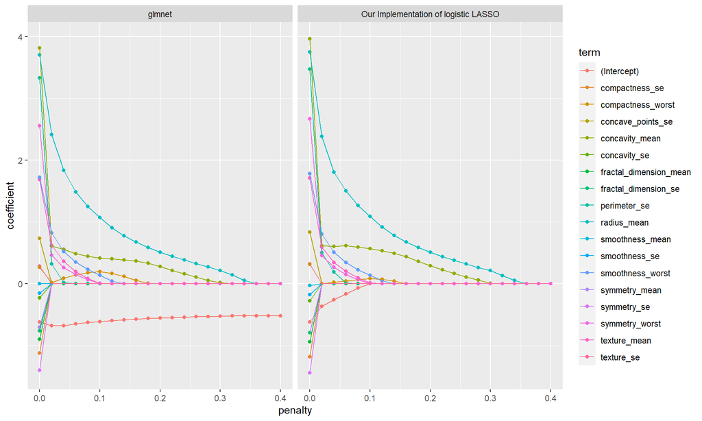

```r
for_viz %>% ggplot(aes(x = penalty, y = coefficient,color = term))+
        geom_point(aes())+
        geom_line(aes(group = term))+
        facet_wrap(~func)
```

### Cross-Validation to find optimal penalty

We perform a 10 fold CV with 5 repeats each to tune our $\lambda$. We select the best $\lambda$ based on best ROC AUC. Our best $\lambda$ is $0.00475$. We compare our function to `{glmnet}` at $\lambda = 0.00475$.

#### Using grid search to tune lasso

```r
my_model <- logistic_reg(penalty = tune(), mixture = 1) %>%
        set_engine("glmnet") %>%
        set_mode("classification")

ten_fold<- vfold_cv(test_dat, repeats = 5, strata = "diagnosis")

reg_grid <- grid_regular(penalty(), levels = 100)

## Tune the model and pick model based on best roc_AUC
wf <- workflow() %>%
        add_recipe(my_rec) %>% # Workflow
        add_model(my_model)

## Parallel
all_cores <- parallel::detectCores(logical = FALSE)-1
cl <- parallel::makePSOCKcluster(all_cores)
doParallel::registerDoParallel(cl)

tune_lasso_grid <- tune_grid(
        wf,
        ten_fold,
        grid = reg_grid
)

parallel::stopCluster(cl)
```

#### Select the best penalty term

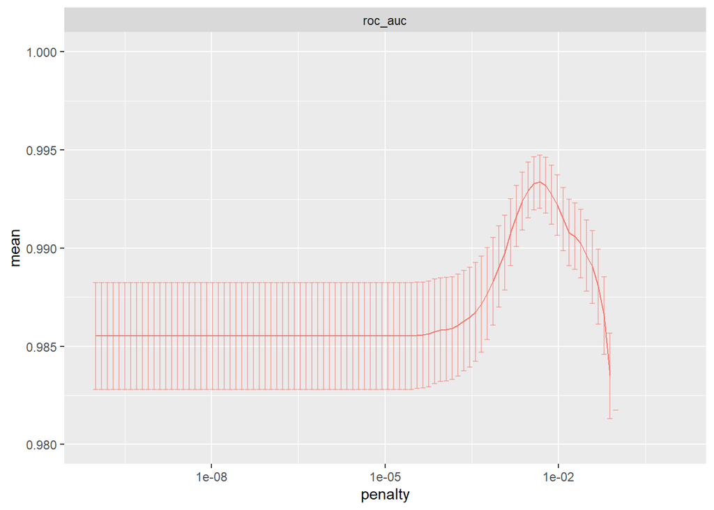

```r
tune_lasso_grid %>%
        collect_metrics() %>% filter(`.metric` == "roc_auc") %>%
        ggplot(aes(penalty, mean, color = `.metric`)) +
        geom_errorbar(aes(
                ymin = mean - std_err,
                ymax = mean + std_err),
                alpha = 0.5) +
        geom_line(size = 0.5) +
        scale_x_log10() +
        facet_wrap(~ `.metric`, scale = "free")+
        theme(legend.position = "none")+
        ylim(0.98,1)
```

```r
min_auc <- tune_lasso_grid %>%
        select_best("roc_auc")
final_wf <- finalize_workflow(
        wf,
        min_auc
)

fit_data <- final_wf %>%
        fit(test_dat) %>%
        pull_workflow_fit() %>% tidy()

our_function<-path_lasso_custom(0.00475) %>% select(-func,-penalty) %>%
        rename("our_function" = coefficient) %>%
        left_join(fit_data, by = "term") %>%
        rename("glmnet" = estimate)
our_function %>% knitr::kable()
```

| term | our_function | glmnet | penalty |
| --- | --- | --- | --- |
| (Intercept) | -0.4616131 | -0.6290945 | 0.0047508 |
| radius_mean | 2.9808754 | 2.9772860 | 0.0047508 |
| texture_mean | 1.0780735 | 1.0957242 | 0.0047508 |
| smoothness_mean | 0.0000000 | 0.0000000 | 0.0047508 |
| concavity_mean | 1.6684822 | 1.6445506 | 0.0047508 |
| symmetry_mean | 0.0000000 | 0.0000000 | 0.0047508 |
| fractal_dimension_mean | -0.1354466 | -0.1629368 | 0.0047508 |
| texture_se | 0.0000000 | 0.0000000 | 0.0047508 |
| perimeter_se | 1.5736338 | 1.4535666 | 0.0047508 |
| smoothness_se | 0.0000000 | 0.0000000 | 0.0047508 |
| compactness_se | -0.4348508 | -0.3553487 | 0.0047508 |
| concavity_se | 0.0000000 | 0.0000000 | 0.0047508 |
| concave_points_se | 0.0000000 | 0.0000000 | 0.0047508 |
| symmetry_se | -0.4557500 | -0.5011653 | 0.0047508 |
| fractal_dimension_se | -0.2679371 | -0.2947295 | 0.0047508 |
| smoothness_worst | 1.1571920 | 1.1613804 | 0.0047508 |
| compactness_worst | 0.0000000 | 0.0000000 | 0.0047508 |
| symmetry_worst | 1.0114985 | 1.0351161 | 0.0047508 |

## Reference

- Hastie, T. J., Tibshirani, R. J., & Wainwright, M. J. (2015). Statistical learning with sparsity: The lasso and generalizations. Boca Raton: CRC Press/Taylor & Francis.
- Silge, J. LASSO regression using tidymodels and #TidyTuesday data for The Office. https://juliasilge.com/blog/lasso-the-office/.\